# Collate condition data

Max Lindmark

16 March, 2023

# Intro

In this script, I load exchange data from datras and extract CA data (i.e. biological data), which is used for the condition model. In theory I could have joined the CPUE data to the CA data and get all important covariates and variables (oxygen, depth, ices information, densities of cod and flounder). However, the CPUE data has been standardized with respect to trawl speed, gear dimension, sweep length and trawl duration. Because many haul id’s did not have this information, the CPUE data has fewer id’s. In order to not lose condition data because I don’t have haul-level CPUE of cod and flounder, I will instead repeat the data cleaning process here, fit models to cod and flounder CPUE and predict at the location of the condition data.

## Load libraries

```r
library(tidyverse)
library(readxl)
library(tidylog)
library(RCurl)
library(viridis)
library(RColorBrewer)
```

```r
library(patchwork)
library(janitor)
library(icesDatras)
library(mapdata)
library(patchwork)
library(rgdal)
library(raster)
library(sf)
library(rgeos)
library(chron)
library(lattice)
library(ncdf4)
library(marmap)
library(rnaturalearth)
library(rnaturalearthdata)
library(mapplots)
library(geosphere)
#remotes::install_github("pbs-assess/sdmTMB")
library(sdmTMB)
```

## For maps

```r
world <- ne_countries(scale = "medium", returnclass = "sf")

# Specify map ranges
ymin = 54; ymax = 58; xmin = 12; xmax = 22

map_data <- rnaturalearth::ne_countries(
  scale = "medium",
  returnclass = "sf", continent = "europe")

# Crop the polygon for plotting and efficiency:
# st_bbox(map_data) # find the rough coordinates
sf::sf_use_s2(FALSE)
# https://stackoverflow.com/questions/68478179/how-to-resolve-spherical-geometry-failures-when-joining-spatial-data

swe_coast <- suppressWarnings(suppressMessages(
  st_crop(map_data,
          c(xmin = xmin, ymin = ymin, xmax = xmax, ymax = ymax))))

# Transform our map into UTM 33 coordinates, which is the equal-area projection we fit in:
utm_zone33 <- 32633
swe_coast_proj <- sf::st_transform(swe_coast, crs = utm_zone33)

#ggplot(swe_coast_proj) + geom_sf()

theme_plot <- function(base_size = 10, base_family = "") {
  theme_light(base_size = 10, base_family = "") +
    theme(
      axis.text.x = element_text(angle = 90),
      axis.text = element_text(size = 8),
      legend.text = element_text(size = 8),
      legend.title = element_text(size = 8),
      legend.position = "bottom",
      legend.key.height = unit(0.2, "cm"),
      legend.margin = margin(0, 0, 0, 0),
      legend.box.margin = margin(-5, -5, -5, -5),
      strip.text = element_text(size = 8, colour = 'gray10', margin = margin(b = 1, t = 1)),
      strip.background = element_rect(fill = "grey95")
      )
}
```

## Read data

```r
# Read HH data
bits_hh <- read.csv("data/DATRAS_exchange/bits_hh.csv") %>% filter(Quarter == 4)

# Read CA data
bits_ca <- read.csv("data/DATRAS_exchange/bits_ca.csv") %>% filter(Quarter == 4)
```

## Standardize catch data

### Standardize ships

```r
# Before creating a a new ID, make sure that countries and ships names use the same format
sort(unique(bits_hh$Ship))
```

```
#>  [1] "06S1" "06SL" "26D4" "26HF" "26HI" "67BC" "77AR" "77SE" "AA36" "ESLF"
#> [11] "ESOR" "ESTM" "LTDA" "RUJB" "RUNT"
```

```r
# Change back to the old Ship name standard...
# https://vocab.ices.dk/?ref=315
# https://vocab.ices.dk/?ref=315
# Assumptions:
# SOL is Solea on ICES links above, and SOL1 is the older one of the two SOLs (1 and 2)
# DAN is Dana
# sweep %>% filter(Ship == "DANS") %>% distinct(Year, Country)
# sweep %>% filter(Ship == "DAN2") %>% distinct(Year)
# bits_hh %>% filter(Ship == "67BC") %>% distinct(Year, Country)
# sweep %>% filter(Ship == "DAN2") %>% distinct(Year)
# bits_hh %>% filter(Ship == "26D4") %>% distinct(Year) # Strange that 26DF doesn't extend far back. Which ship did the Danes use? Ok, I have no Danish data that old.
# bits_hh %>% filter(Country == "DK") %>% distinct(Year)

bits_hh <- bits_hh %>%
  mutate(Ship2 = fct_recode(Ship,
                            "SOL" = "06S1",
                            "SOL2" = "06SL",
                            "DAN2" = "26D4",
                            "HAF" = "26HF",
                            "HAF" = "26HI",
                            "HAF" = "67BC",
                            "BAL" = "67BC",
                            "ARG" = "77AR",
                            "77SE" = "77SE",
                            "AA36" = "AA36",
                            "KOOT" = "ESLF",
                            "KOH" = "ESTM",
                            "DAR" = "LTDA",
                            "ATLD" = "RUJB",
                            "ATL" = "RUNT"),
         Ship2 = as.character(Ship2)) %>%
  mutate(Ship3 = ifelse(Country == "LV" & Ship2 == "BAL", "BALL", Ship2))

bits_ca <- bits_ca %>%
  mutate(Ship2 = fct_recode(Ship,
                            "SOL" = "06S1",
                            "SOL2" = "06SL",
                            "DAN2" = "26D4",
                            "HAF" = "26HF",
                            "HAF" = "26HI",
                            "HAF" = "67BC",
                            "BAL" = "67BC",
                            "ARG" = "77AR",
                            "77SE" = "77SE",
                            "AA36" = "AA36",
                            "KOOT" = "ESLF",
                            "KOH" = "ESTM",
                            "DAR" = "LTDA",
                            "ATLD" = "RUJB",
                            "ATL" = "RUNT"),
         Ship2 = as.character(Ship2)) %>%
  mutate(Ship3 = ifelse(Country == "LV" & Ship2 == "BAL", "BALL", Ship2))
```

### Standardize countries

```r
# Now check which country codes are used
sort(unique(bits_hh$Country))
```

```
#> [1] "DE" "DK" "EE" "LT" "LV" "PL" "RU" "SE"
```

```r
# https://www.nationsonline.org/oneworld/country_code_list.htm#E
bits_hh <- bits_hh %>%
  mutate(Country = fct_recode(Country,
                              "DEN" = "DK",
                              "EST" = "EE",
                              "GFR" = "DE",
                              "LAT" = "LV",
                              "LTU" = "LT",
                              "POL" = "PL",
                              "RUS" = "RU",
                              "SWE" = "SE"),
         Country = as.character(Country))

bits_ca <- bits_ca %>%
  mutate(Country = fct_recode(Country,
                              "DEN" = "DK",
                              "EST" = "EE",
                              "GFR" = "DE",
                              "LAT" = "LV",
                              "LTU" = "LT",
                              "POL" = "PL",
                              "RUS" = "RU",
                              "SWE" = "SE"),
         Country = as.character(Country))

# Gear? Are they the same?
sort(unique(bits_hh$Gear))
```

```
#>  [1] "ESB" "EXP" "FOT" "GOV" "GRT" "H20" "LBT" "PEL" "SON" "TVL" "TVS"
```

### Create a simple ID that works across all exchange data

```r
# Create ID column
bits_ca <- bits_ca %>%
  mutate(IDx = paste(Year, Quarter, Country, Ship, Gear, StNo, HaulNo, sep = "."))

bits_hh <- bits_hh %>%
  mutate(IDx = paste(Year, Quarter, Country, Ship, Gear, StNo, HaulNo, sep = "."))

# Works like a haul-id
# bits_hh %>% group_by(IDx) %>% mutate(n = n()) %>% ungroup() %>% distinct(n)
```

### Create the same unique haul-ID in the cpue data that I have in the sweep-file

```r
bits_hh <- bits_hh %>%
  mutate(haul.id = paste(Year, Quarter, Country, Ship3, Gear, StNo, HaulNo, sep = ":"))

bits_hh %>%
  distinct(haul.id, .keep_all = TRUE) %>%
  group_by(Month) %>%
  summarise(n = n()) %>%
  ungroup() %>%
  mutate((prop = n / sum(n)) * 100)
```

```
#> # A tibble: 4 × 3
#>   Month     n `(prop = n/sum(n)) * 100`
#>   <int> <int>                     <dbl>
#> 1     9    15                     0.230
#> 2    10   927                    14.2
#> 3    11  4948                    75.9
#> 4    12   633                     9.70
```

### Clean DATRAS EXCHANGE data

```r
# Select just valid, additional and no oxygen hauls
bits_hh <- bits_hh %>%
  filter(HaulVal %in% c("A","N","V"))

# Add ICES rectangle
bits_hh$Rect <- mapplots::ices.rect2(lon = bits_hh$ShootLong, lat = bits_hh$ShootLat)

# Add ICES subdivisions
shape <- shapefile("data/ICES_StatRec_mapto_ICES_Areas/StatRec_map_Areas_Full_20170124.shp")

pts <- SpatialPoints(cbind(bits_hh$ShootLong, bits_hh$ShootLat),
                     proj4string = CRS(proj4string(shape)))
bits_hh$sub_div <- over(pts, shape)$Area_27

# Rename subdivisions to the more common names and do some more filtering (by sub div and area)
sort(unique(bits_hh$sub_div))
```

```
#>  [1] "3.a.20"   "3.a.21"   "3.b.23"   "3.c.22"   "3.d.24"   "3.d.25"
#>  [7] "3.d.26"   "3.d.27"   "3.d.28.1" "3.d.28.2" "3.d.29"
```

```r
bits_hh <- bits_hh %>%
  mutate(sub_div = factor(sub_div),
         sub_div = fct_recode(sub_div,
                              "20" = "3.a.20",
                              "21" = "3.a.21",
                              "22" = "3.c.22",
                              "23" = "3.b.23",
                              "24" = "3.d.24",
                              "25" = "3.d.25",
                              "26" = "3.d.26",
                              "27" = "3.d.27",
                              "28" = "3.d.28.1",
                              "28" = "3.d.28.2",
                              "29" = "3.d.29",
                              "30" = "3.d.30"),
         sub_div = as.character(sub_div))
# Match columns from the HH data to the HL and CA data
sort(unique(bits_hh$sub_div))
```

```
#>  [1] "20" "21" "22" "23" "24" "25" "26" "27" "28" "29"
```

```r
sort(colnames(bits_hh))
```

```
#>  [1] "BotCurDir"         "BotCurSpeed"       "BotSal"
#>  [4] "BotTemp"           "Buoyancy"          "BySpecRecCode"
#>  [7] "CodendMesh"        "Country"           "DataType"
#> [10] "DateofCalculation" "Day"               "DayNight"
#> [13] "Depth"             "DepthStratum"      "Distance"
#> [16] "DoorSpread"        "DoorSurface"       "DoorType"
#> [19] "DoorWgt"           "Gear"              "GearEx"
#> [22] "GroundSpeed"       "haul.id"           "HaulDur"
#> [25] "HaulLat"           "HaulLong"          "HaulNo"
#> [28] "HaulVal"           "HydroStNo"         "IDx"
#> [31] "KiteDim"           "MaxTrawlDepth"     "MinTrawlDepth"
#> [34] "Month"             "Netopening"        "PelSampType"
#> [37] "Quarter"           "RecordType"        "Rect"
#> [40] "Rigging"           "SecchiDepth"       "Ship"
#> [43] "Ship2"             "Ship3"             "ShootLat"
#> [46] "ShootLong"         "SpeedWater"        "StatRec"
#> [49] "StdSpecRecCode"    "StNo"              "sub_div"
#> [52] "SurCurDir"         "SurCurSpeed"       "SurSal"
#> [55] "SurTemp"           "Survey"            "SweepLngt"
#> [58] "SwellDir"          "SwellHeight"       "ThClineDepth"
#> [61] "ThermoCline"       "Tickler"           "TidePhase"
#> [64] "TideSpeed"         "TimeShot"          "TowDir"
#> [67] "Turbidity"         "WarpDen"           "Warpdia"
#> [70] "Warplngt"          "WgtGroundRope"     "WindDir"
#> [73] "WindSpeed"         "WingSpread"        "X"
#> [76] "Year"
```

```r
bits_hh_merge <- bits_hh %>%
                       dplyr::select(sub_div, Rect, HaulVal, StdSpecRecCode, BySpecRecCode,
                                     IDx, ShootLat, ShootLong, Month, Day)

bits_ca <- left_join(bits_ca, bits_hh_merge, by = "IDx")

# Now filter the subdivisions I want from all data sets
bits_hh <- bits_hh %>% filter(sub_div %in% c(24, 25, 26, 27, 28))
bits_ca <- bits_ca %>% filter(sub_div %in% c(24, 25, 26, 27, 28))
```

```r
library(lubridate)
bits_ca$Date <- as.Date(paste(bits_ca$Year, bits_ca$Month, bits_ca$Day, sep = "-"))

bits_ca$yday <- yday(bits_ca$Date)
```

### Now clean the CA data and go to 1 row 1 observation

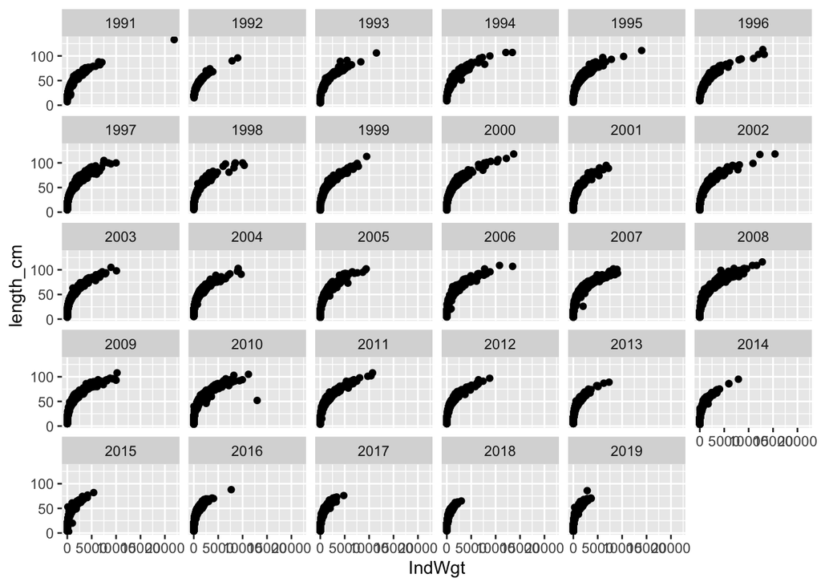

```r
bits_ca <- bits_ca %>%
  filter(SpecCode %in% c("164712", "126436") & Year < 2020) %>%
  mutate(Species = "Cod")

# Now I need to copy rows with NoAtLngt > 1 so that 1 row = 1 ind
# First make a small test
# nrow(bits_ca)
# test_id <- head(filter(bits_ca, CANoAtLngt == 5))$ID[1]
# filter(bits_ca, ID == test_id & CANoAtLngt == 5)

bits_ca <- bits_ca %>% map_df(., rep, .$CANoAtLngt)

# head(data.frame(filter(bits_ca, ID == test_id & CANoAtLngt == 5)), 20)
# nrow(bits_ca)
# Looks ok!

# Standardize length and drop NA weights (need that for condition)
bits_ca <- bits_ca %>%
  drop_na(IndWgt) %>%
  drop_na(LngtClass) %>%
  filter(IndWgt > 0 & LngtClass > 0) %>%  # Filter positive length and weight
  mutate(weight_g = IndWgt) %>%
  mutate(length_cm = ifelse(LngtCode == ".",
                            LngtClass/10,
                            LngtClass)) # Standardize length (https://vocab.ices.dk/?ref=18)

# Plot
ggplot(bits_ca, aes(IndWgt, length_cm)) +
  geom_point() +
  facet_wrap(~Year)
```

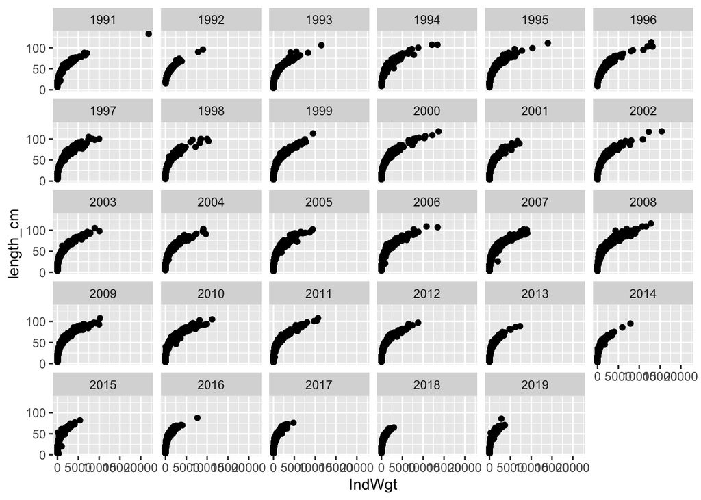

```r
# Remove apparent outlier
bits_ca <- bits_ca %>%
  mutate(keep = ifelse(Year == 2010 & IndWgt > 12500, "N", "Y")) %>%
  filter(keep == "Y") %>% dplyr::select(-keep)

# bits_ca %>%
#   mutate(fulton_k = (IndWgt / (length_cm^3)) * 100) %>%
#   filter(fulton_k < 10) %>%
#   ggplot(aes(yday, fulton_k)) + geom_point() + stat_smooth()

ggplot(bits_ca, aes(IndWgt, length_cm)) +
  geom_point() +
  facet_wrap(~Year)
```

```r
# Rename things and select specific columns
dat <- bits_ca %>% rename("year" = "Year",
                          "lat" = "ShootLat",
                          "lon" = "ShootLong",
                          "quarter" = "Quarter",
                          "ices_rect" = "Rect") %>%
  dplyr::select(weight_g, length_cm, year, lat, lon, quarter, IDx, ices_rect, sub_div)

# > nrow(dat)
# [1] 98863
```

dat %>% drop_na(weight_g) %>% filter(year > 1992) %>% ggplot(., aes(lon, lat)) + geom_point(size = 0.1) + facet_wrap(~year)

## Add in the environmental variables

### Depth

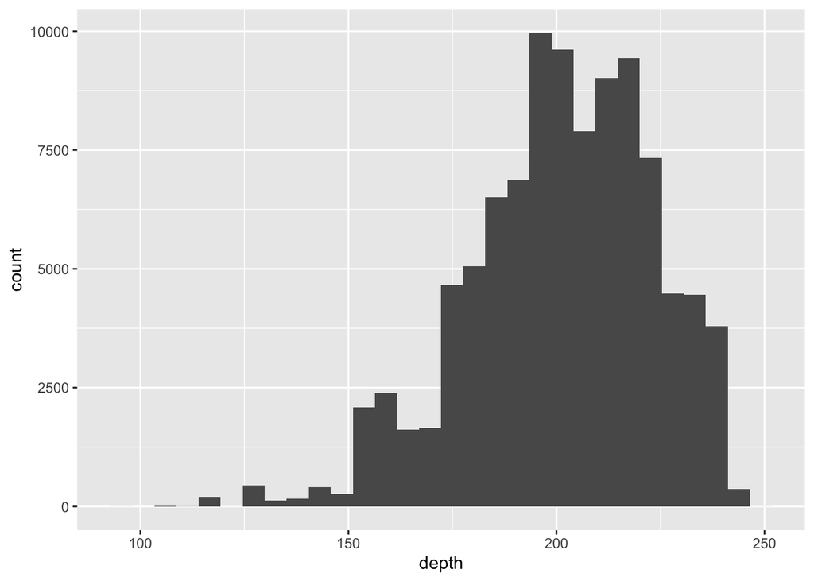

```r
# Read the tifs
west <- raster("data/depth_geo_tif/D5_2018_rgb-1.tif")
#plot(west)

east <- raster("data/depth_geo_tif/D6_2018_rgb-1.tif")
# plot(east)

dep_rast <- raster::merge(west, east)

dat$depth <- extract(dep_rast, dat %>% dplyr::select(lon, lat), method = "bilinear")

# Convert to depth (instead of elevation)
ggplot(dat, aes(depth)) + geom_histogram()
```

```r
dat$depth <- (dat$depth - max(drop_na(dat)$depth)) *-1
```

```
#> drop_na: no rows removed
```

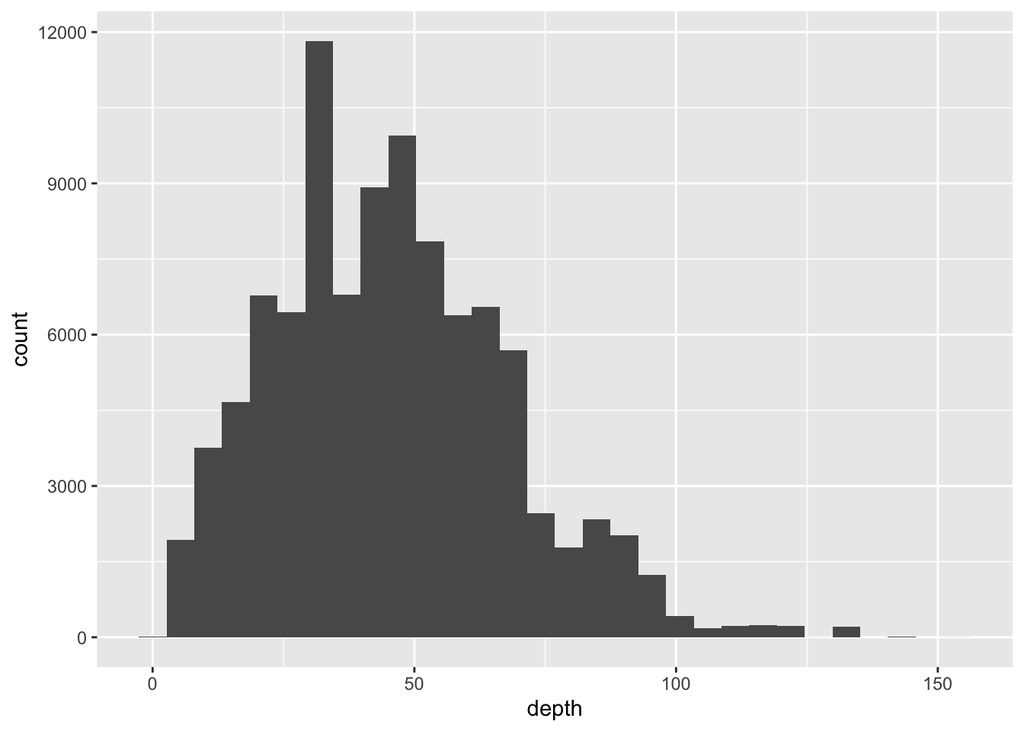

```r
ggplot(dat, aes(depth)) + geom_histogram()
```

### Oxygen

```r
# Downloaded from here: https://resources.marine.copernicus.eu/?option=com_csw&view=details&product_id=BALTICSEA_REANALYSIS_BIO_003_012
# Extract raster points: https://gisday.wordpress.com/2014/03/24/extract-raster-values-from-points-using-r/comment-page-1/
# https://rpubs.com/boyerag/297592
# https://pjbartlein.github.io/REarthSysSci/netCDF.html#get-a-variable
# Open the netCDF file
ncin <- nc_open("data/NEMO_Nordic_SCOBI/dataset-reanalysis-scobi-monthlymeans_1610091357600.nc")

print(ncin)
```

```
#> File data/NEMO_Nordic_SCOBI/dataset-reanalysis-scobi-monthlymeans_1610091357600.nc (NC_FORMAT_CLASSIC):
#>
#>      1 variables (excluding dimension variables):
#>         float o2b[longitude,latitude,time]
#>             long_name: Sea_floor_Dissolved_Oxygen_Concentration
#>             missing_value: NaN
#>             standard_name: mole_concentration_of_dissolved_molecular_oxygen_in_sea_water
#>             units: mmol m-3
#>             _FillValue: NaN
#>             _ChunkSizes: 1
#>              _ChunkSizes: 523
#>              _ChunkSizes: 383
#>
#>      3 dimensions:
#>         time  Size:324
#>             axis: T
#>             long_name: Validity time
#>             standard_name: time
#>             units: days since 1950-01-01 00:00:00
#>             calendar: gregorian
#>             _ChunkSizes: 512
#>             _CoordinateAxisType: Time
#>             valid_min: 15721.5
#>             valid_max: 25551.5
#>         latitude  Size:166
#>             axis: Y
#>             standard_name: latitude
#>             long_name: latitude
#>             units: degrees_north
#>             _CoordinateAxisType: Lat
#>             valid_min: 52.991626739502
#>             valid_max: 58.4915390014648
#>         longitude  Size:253
#>             standard_name: longitude
#>             long_name: longitude
#>             units: degrees_east
#>             axis: X
#>             _CoordinateAxisType: Lon
#>             valid_min: 9.01375484466553
#>             valid_max: 23.013614654541
```

[output cut: 11 more lines]

```
#>         FROM_ORIGINAL_FILE__easternmost_longitude: 30.2357654571533
#>         FROM_ORIGINAL_FILE__northernmost_latitude: 65.8914184570312
#>         FROM_ORIGINAL_FILE__westernmost_longitude: 9.01375484466553
#>         FROM_ORIGINAL_FILE__southernmost_latitude: 48.49169921875
#>         shallowest_depth: 1.50136542320251
#>         deepest_depth: 711.059204101562
#>         source: SMHI reanalysis run NORDIC-NS2_1d_20191201_20191202
#>         file_quality_index: 1
#>         creation_date: 2020-11-16 UTC
#>         bullentin_date: 20191201
#>         start_date: 2019-12-01 UTC
#>         stop_date: 2019-12-01 UTC
#>         start_time: 00:00 UTC
#>         stop_time: 00:00 UTC
#>         _CoordSysBuilder: ucar.nc2.dataset.conv.CF1Convention
```

```r
# Get longitude and latitude
lon <- ncvar_get(ncin,"longitude")
nlon <- dim(lon)
head(lon)
```

```
#> [1] 9.013755 9.069310 9.124865 9.180420 9.235975 9.291530
```

```r
lat <- ncvar_get(ncin,"latitude")
nlat <- dim(lat)
head(lat)
```

```
#> [1] 52.99163 53.02496 53.05829 53.09163 53.12496 53.15829
```

```r
# Get time
time <- ncvar_get(ncin,"time")
time
```

```
#>   [1] 15721.5 15751.0 15780.5 15811.0 15841.5 15872.0 15902.5 15933.5 15964.0
#>  [10] 15994.5 16025.0 16055.5 16086.5 16116.0 16145.5 16176.0 16206.5 16237.0
#>  [19] 16267.5 16298.5 16329.0 16359.5 16390.0 16420.5 16451.5 16481.0 16510.5
#>  [28] 16541.0 16571.5 16602.0 16632.5 16663.5 16694.0 16724.5 16755.0 16785.5
#>  [37] 16816.5 16846.5 16876.5 16907.0 16937.5 16968.0 16998.5 17029.5 17060.0
#>  [46] 17090.5 17121.0 17151.5 17182.5 17212.0 17241.5 17272.0 17302.5 17333.0
#>  [55] 17363.5 17394.5 17425.0 17455.5 17486.0 17516.5 17547.5 17577.0 17606.5
#>  [64] 17637.0 17667.5 17698.0 17728.5 17759.5 17790.0 17820.5 17851.0 17881.5
#>  [73] 17912.5 17942.0 17971.5 18002.0 18032.5 18063.0 18093.5 18124.5 18155.0
#>  [82] 18185.5 18216.0 18246.5 18277.5 18307.5 18337.5 18368.0 18398.5 18429.0
#>  [91] 18459.5 18490.5 18521.0 18551.5 18582.0 18612.5 18643.5 18673.0 18702.5
#> [100] 18733.0 18763.5 18794.0 18824.5 18855.5 18886.0 18916.5 18947.0 18977.5
#> [109] 19008.5 19038.0 19067.5 19098.0 19128.5 19159.0 19189.5 19220.5 19251.0
#> [118] 19281.5 19312.0 19342.5 19373.5 19403.0 19432.5 19463.0 19493.5 19524.0
#> [127] 19554.5 19585.5 19616.0 19646.5 19677.0 19707.5 19738.5 19768.5 19798.5
```

[output cut: 21 more lines]

```r
tunits <- ncatt_get(ncin,"time","units")
nt <- dim(time)
nt
```

```
#> [1] 324
```

```r
tunits
```

```
#> $hasatt
#> [1] TRUE
#>
#> $value
#> [1] "days since 1950-01-01 00:00:00"
```

```r
# Get oxygen
dname <- "o2b"

oxy_array <- ncvar_get(ncin,dname)
dlname <- ncatt_get(ncin,dname,"long_name")
dunits <- ncatt_get(ncin,dname,"units")
fillvalue <- ncatt_get(ncin,dname,"_FillValue")
dim(oxy_array)
```

```
#> [1] 253 166 324
```

```r
# Get global attributes
title <- ncatt_get(ncin,0,"title")
institution <- ncatt_get(ncin,0,"institution")
datasource <- ncatt_get(ncin,0,"source")
references <- ncatt_get(ncin,0,"references")
history <- ncatt_get(ncin,0,"history")
Conventions <- ncatt_get(ncin,0,"Conventions")

# Convert time: split the time units string into fields
tustr <- strsplit(tunits$value, " ")
tdstr <- strsplit(unlist(tustr)[3], "-")
tmonth <- as.integer(unlist(tdstr)[2])
tday <- as.integer(unlist(tdstr)[3])
tyear <- as.integer(unlist(tdstr)[1])

# Here I deviate from the guide a little bit. Save this info:
dates <- chron(time, origin = c(tmonth, tday, tyear))

# Crop the date variable
months <- as.numeric(substr(dates, 2, 3))
years <- as.numeric(substr(dates, 8, 9))
years <- ifelse(years > 90, 1900 + years, 2000 + years)

# Replace netCDF fill values with NA's
oxy_array[oxy_array == fillvalue$value] <- NA

# We only use Quarter 4 in this analysis, so now we want to loop through each time step,
# and if it is a good month save it as a raster.
# First get the index of months that correspond to Q4
months
```

```
#>   [1]  1  2  3  4  5  6  7  8  9 10 11 12  1  2  3  4  5  6  7  8  9 10 11 12  1
#>  [26]  2  3  4  5  6  7  8  9 10 11 12  1  2  3  4  5  6  7  8  9 10 11 12  1  2
#>  [51]  3  4  5  6  7  8  9 10 11 12  1  2  3  4  5  6  7  8  9 10 11 12  1  2  3
#>  [76]  4  5  6  7  8  9 10 11 12  1  2  3  4  5  6  7  8  9 10 11 12  1  2  3  4
#> [101]  5  6  7  8  9 10 11 12  1  2  3  4  5  6  7  8  9 10 11 12  1  2  3  4  5
#> [126]  6  7  8  9 10 11 12  1  2  3  4  5  6  7  8  9 10 11 12  1  2  3  4  5  6
#> [151]  7  8  9 10 11 12  1  2  3  4  5  6  7  8  9 10 11 12  1  2  3  4  5  6  7
#> [176]  8  9 10 11 12  1  2  3  4  5  6  7  8  9 10 11 12  1  2  3  4  5  6  7  8
#> [201]  9 10 11 12  1  2  3  4  5  6  7  8  9 10 11 12  1  2  3  4  5  6  7  8  9
#> [226] 10 11 12  1  2  3  4  5  6  7  8  9 10 11 12  1  2  3  4  5  6  7  8  9 10
#> [251] 11 12  1  2  3  4  5  6  7  8  9 10 11 12  1  2  3  4  5  6  7  8  9 10 11
#> [276] 12  1  2  3  4  5  6  7  8  9 10 11 12  1  2  3  4  5  6  7  8  9 10 11 12
#> [301]  1  2  3  4  5  6  7  8  9 10 11 12  1  2  3  4  5  6  7  8  9 10 11 12
```

```r
index_keep <- which(months > 9)

oxy_q4 <- oxy_array[, , index_keep]

months_keep <- months[index_keep]

years_keep <- years[index_keep]

# Now we have an array with only Q4 data...
# We need to now calculate the average within a year.
# Get a sequence that takes every third value between 1: number of months (length)
loop_seq <- seq(1, dim(oxy_q4)[3], by = 3)

# Create objects that will hold data
dlist <- list()
oxy_10 <- c()
oxy_11 <- c()
oxy_12 <- c()
oxy_ave <- c()

# Loop through the vector sequence with every third value, then take the average of
# three consecutive months (i.e. q4)
for(i in loop_seq) {

  oxy_10 <- oxy_q4[, , (i)]
  oxy_11 <- oxy_q4[, , (i + 1)]
  oxy_12 <- oxy_q4[, , (i + 2)]

  oxy_ave <- (oxy_10 + oxy_11 + oxy_12) / 3

  list_pos <- ((i/3) - (1/3)) + 1 # to get index 1:n(years)

  dlist[[list_pos]] <- oxy_ave

}

# Now name the lists with the year:
names(dlist) <- unique(years_keep)

# Now I need to make a loop where I extract the raster value for each year...
# The cpue data is called dat so far in this script

# Filter years in the cpue data frame to only have the years I have oxygen for
d_sub_oxy <- dat %>% filter(year %in% names(dlist)) %>% droplevels()
```

```
#> filter: removed 1,305 rows (1%), 97,558 rows remaining
```

```r
# Create data holding object
data_list <- list()

# ... And for the oxygen raster
raster_list <- list()

# Create factor year for indexing the list in the loop
d_sub_oxy$year_f <- as.factor(d_sub_oxy$year)

# Loop through each year and extract raster values for the cpue data points
for(i in unique(d_sub_oxy$year_f)) {

  # Set plot limits
  ymin = 54; ymax = 58; xmin = 12; xmax = 22

  # Subset a year
  oxy_slice <- dlist[[i]]

  # Create raster for that year (i)
  r <- raster(t(oxy_slice), xmn = min(lon), xmx = max(lon), ymn = min(lat), ymx = max(lat),
              crs = CRS("+proj=longlat +ellps=WGS84 +datum=WGS84 +no_defs+ towgs84=0,0,0"))

  # Flip...
  r <- flip(r, direction = 'y')

  #plot(r, main = i)

  # Filter the same year (i) in the cpue data and select only coordinates
  d_slice <- d_sub_oxy %>% filter(year_f == i) %>% dplyr::select(lon, lat)

  # Make into a SpatialPoints object
  data_sp <- SpatialPoints(d_slice)

  # Extract raster value (oxygen)
  rasValue <- raster::extract(r, data_sp, method = "bilinear")

  # Now we want to plot the results of the raster extractions by plotting the cpue
  # data points over a raster and saving it for each year.
  # Make the SpatialPoints object into a raster again (for pl)
  df <- as.data.frame(data_sp)

  # Add in the raster value in the df holding the coordinates for the cpue data
  d_slice$oxy <- rasValue

  # Add in which year
  d_slice$year <- i

  # Create a index for the data last where we store all years (because our loop index
  # i is not continuous, we can't use it directly)
  index <- as.numeric(d_slice$year)[1] - 1992

  # Add each years' data in the list
  data_list[[index]] <- d_slice

  # Save to check each year is ok! First convert the raster to points for plotting
  # (so that we can use ggplot)
  map.p <- rasterToPoints(r)

  # Make the points a dataframe for ggplot
  df_rast <- data.frame(map.p)

  # Rename y-variable and add year
  df_rast <- df_rast %>% rename("oxy" = "layer") %>% mutate(year = i)

  # Add each years' raster data frame in the list
  raster_list[[index]] <- df_rast

  # Make appropriate column headings
  colnames(df_rast) <- c("Longitude", "Latitude", "oxy")

  # Now make the map
  ggplot(data = df_rast, aes(y = Latitude, x = Longitude)) +
    geom_raster(aes(fill = oxy)) +
    geom_point(data = d_slice, aes(x = lon, y = lat, fill = oxy),
               color = "black", size = 5, shape = 21) +
    theme_plot() +
    geom_sf(data = world, inherit.aes = F, size = 0.2) +
    coord_sf(xlim = c(xmin, xmax),
             ylim = c(ymin, ymax)) +
    scale_colour_gradientn(colours = rev(terrain.colors(10)),
                           limits = c(-200, 400)) +
    scale_fill_gradientn(colours = rev(terrain.colors(10)),
                         limits = c(-200, 400))

  ggsave(paste("figures/supp/condition/cond_oxygen_rasters/", i,".png", sep = ""),
         width = 6.5, height = 6.5, dpi = 600)

}
```

[output not shown]

[output cut: 26 more lines]

[output not shown]

```
#> group_by: one grouping variable (year)
#> drop_na (grouped): no rows removed
#> summarise: now 27 rows and 2 columns, ungrouped
#> mutate: new variable 'year_num' (double) with 27 unique values and 0% NA
```

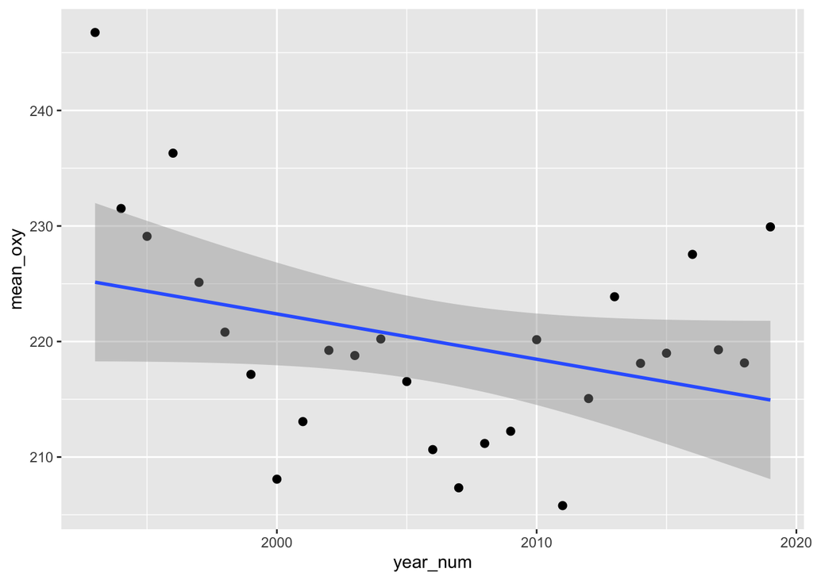

```r
# Now create a data frame from the list of all annual values
big_dat_oxy <- dplyr::bind_rows(data_list)
big_raster_dat_oxy <- dplyr::bind_rows(raster_list)

# Plot data, looks like there's big inter-annual variation but a negative trend over time
big_raster_dat_oxy %>%
  group_by(year) %>%
  drop_na(oxy) %>%
  summarise(mean_oxy = mean(oxy)) %>%
  mutate(year_num = as.numeric(year)) %>%
  ggplot(., aes(year_num, mean_oxy)) +
  geom_point(size = 2) +
  stat_smooth(method = "lm")
```

```
#> group_by: one grouping variable (year)
#> drop_na (grouped): no rows removed
#> mutate (grouped): new variable 'dead' (character) with 2 unique values and 0% NA
#> filter (grouped): removed 437,238 rows (93%), 31,671 rows remaining
#> mutate (grouped): new variable 'n' (integer) with 27 unique values and 0% NA
#>                   new variable 'year_num' (double) with 27 unique values and 0% NA
```

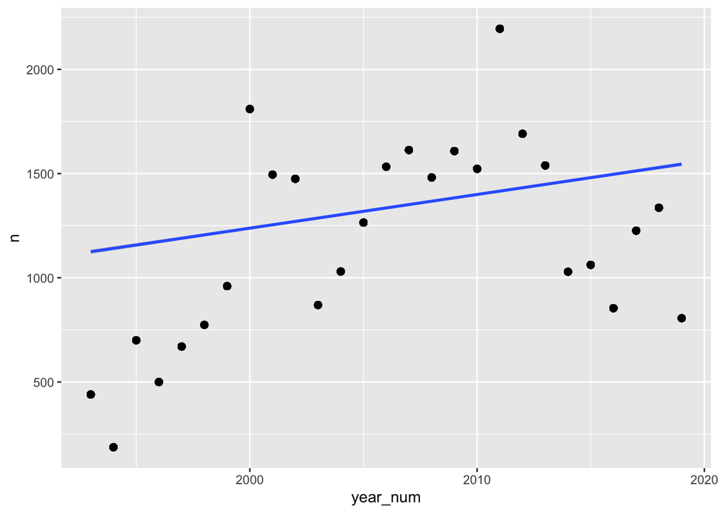

```r
big_raster_dat_oxy %>%
  group_by(year) %>%
  drop_na(oxy) %>%
  mutate(dead = ifelse(oxy < 0, "Y", "N")) %>%
  filter(dead == "Y") %>%
  mutate(n = n(),
         year_num = as.numeric(year)) %>%
  ggplot(., aes(year_num, n)) +
  geom_point(size = 2) +
  stat_smooth(method = "lm")
```

```r
# Now add in the new oxygen column in the original data:
str(d_sub_oxy)
```

```
#> tibble [97,558 × 11] (S3: tbl_df/tbl/data.frame)
#>  $ weight_g : num [1:97558] 11 120 1416 25 733 ...
#>  $ length_cm: num [1:97558] 10 22 51 14 41 41 42 43 43 43 ...
#>  $ year     : int [1:97558] 1993 1993 1993 1993 1993 1993 1993 1993 1993 1993 ...
#>  $ lat      : num [1:97558] 54.7 54.7 54.7 54.5 54.5 ...
#>  $ lon      : num [1:97558] 13.1 13.1 13.1 14.3 14.3 ...
#>  $ quarter  : int [1:97558] 4 4 4 4 4 4 4 4 4 4 ...
#>  $ IDx      : chr [1:97558] "1993.4.GFR.06S1.H20.21.65" "1993.4.GFR.06S1.H20.21.65" "1993.4.GFR.06S1.H20.21.65" "1993.4.GFR.06S1.H20.22.43" ...
#>  $ ices_rect: chr [1:97558] "38G3" "38G3" "38G3" "38G4" ...
#>  $ sub_div  : chr [1:97558] "24" "24" "24" "24" ...
#>  $ depth    : num [1:97558] 7.87 7.87 7.87 6.87 6.87 ...
#>  $ year_f   : Factor w/ 27 levels "1993","1994",..: 1 1 1 1 1 1 1 1 1 1 ...
```

```r
str(big_dat_oxy)
```

```
#> tibble [97,558 × 4] (S3: tbl_df/tbl/data.frame)
#>  $ lon : num [1:97558] 13.1 13.1 13.1 14.3 14.3 ...
#>  $ lat : num [1:97558] 54.7 54.7 54.7 54.5 54.5 ...
#>  $ oxy : num [1:97558] 322 322 322 350 350 ...
#>  $ year: chr [1:97558] "1993" "1993" "1993" "1993" ...
```

```r
# Create an ID for matching the oxygen data with the cpue data
dat$id_oxy <- paste(dat$year, dat$lon, dat$lat, sep = "_")
big_dat_oxy$id_oxy <- paste(big_dat_oxy$year, big_dat_oxy$lon, big_dat_oxy$lat, sep = "_")

# Which id's are not in the cpue data (dat)?
ids <- dat$id_oxy[!dat$id_oxy %in% c(big_dat_oxy$id_oxy)]

unique(ids)
```

```
#>  [1] "1991_13.8_54.5167"    "1991_13.45_54.75"     "1991_13.5667_54.7167"
#>  [4] "1991_13.6667_54.6833" "1991_13.8_54.65"      "1991_13.85_54.7833"
#>  [7] "1991_13.7_54.75"      "1991_13.95_54.9333"   "1991_13.6833_54.9833"
#> [10] "1991_13.1167_54.95"   "1991_13.2435_54.9697" "1991_14.15_54.5167"
#> [13] "1991_14.0333_54.85"   "1991_14.1167_54.6667" "1991_14.0833_54.5833"
#> [16] "1991_14.25_54.6"      "1991_13.4833_55.0167" "1991_13.6_55.0333"
#> [19] "1991_13.85_55.1"      "1991_13.9042_55.0183" "1991_13.2772_55.21"
#> [22] "1991_13.6492_55.2135" "1991_15.6596_55.4523" "1991_15.3273_55.9365"
#> [25] "1991_15.3685_55.95"   "1991_15.9797_55.8632" "1991_16.0537_55.7407"
#> [28] "1991_16.431_55.5713"  "1991_16.4383_55.6667" "1991_17.668_55.8398"
#> [31] "1991_17.0363_55.9378" "1991_17.7227_56.0398" "1991_18.4345_56.224"
#> [34] "1991_18.7987_57.1543" "1991_18.9297_57.112"  "1991_18.8237_57.0395"
#> [37] "1991_19.1567_57.3528" "1991_14.4605_55.4568" "1991_14.2167_55.15"
#> [40] "1991_14.2833_55.1833" "1991_14.2833_55"      "1991_14.488_55.6708"
#> [43] "1991_14.7052_55.574"  "1991_17.5455_57.496"  "1991_18.1203_57.8185"
#> [46] "1991_19.406_57.8703"  "1991_19.5915_57.8896" "1991_17.0417_57.5"
#> [49] "1992_13.6333_55"      "1992_14.1667_55.1333" "1992_14.2833_55.1833"
#> [52] "1992_13.1167_54.7167" "1992_13.3333_54.7"    "1992_13.8_54.5167"
#> [55] "1992_13.55_54.7333"   "1992_13.9_54.5"       "1992_13.65_54.6833"
#> [58] "1992_13.8_54.6333"    "1992_14.3_55.0333"    "1992_14.35_55.1"
#> [61] "1992_13.8167_54.75"   "1992_13.7_54.75"      "1992_13.2_54.8667"
#> [64] "1992_13.1_54.9167"    "1992_13.1167_54.9833" "1992_13.1167_54.65"
#> [67] "1992_13.8833_54.5667" "1992_13.9667_54.9333" "1992_14.2167_54.6333"
#> [70] "1992_14.3667_54.5167" "1992_14.2_54.5"       "1992_14.0333_54.8667"
#> [73] "1992_14.1_54.7"       "1992_14.1333_54.5667" "1992_13.45_55.0167"
#> [76] "1992_13.7667_55.1"    "1992_13.55_55.0333"   "1992_13.8667_55.1"
```

```r
# Select only the columns we want to merge
big_dat_sub_oxy <- big_dat_oxy %>% dplyr::select(id_oxy, oxy)

# Remove duplicate ID (one oxy value per id)
big_dat_sub_oxy2 <- big_dat_sub_oxy %>% distinct(id_oxy, .keep_all = TRUE)
```

```
#> distinct: removed 94,317 rows (97%), 3,241 rows remaining
```

```r
# big_dat_sub_oxy %>% group_by(id_oxy) %>% mutate(n = n()) %>% arrange(desc(n))

# Join the data with raster-derived oxygen with the full cpue data
dat <- left_join(dat, big_dat_sub_oxy2, by = "id_oxy")
```

```
#> left_join: added one column (oxy)
#>            > rows only in x    1,305
#>            > rows only in y  (     0)
#>            > matched rows     97,558
#>            >                 ========
#>            > rows total       98,863
```

```r
# Now the unit of oxygen is mmol/m3. I want it to be ml/L. The original model is in unit ml/L
# and it's been converted by the data host. Since it was converted without accounting for
# pressure or temperature, I can simply use the following conversion factor:
# 1 ml/l = 103/22.391 = 44.661 μmol/l -> 1 ml/l = 0.044661 mmol/l = 44.661 mmol/m^3 -> 0.0223909 ml/l = 1mmol/m^3
# https://ocean.ices.dk/tools/unitconversion.aspx

dat$oxy <- dat$oxy * 0.0223909

# Drop NA oxygen
dat <- dat %>% drop_na(oxy)
```

```
#> drop_na: removed 1,314 rows (1%), 97,549 rows remaining
```

### Temperature

```r
# Open the netCDF file
ncin <- nc_open("data/NEMO_Nordic_SCOBI/dataset-reanalysis-nemo-monthlymeans_1608127623694.nc")

print(ncin)
```

```
#> File data/NEMO_Nordic_SCOBI/dataset-reanalysis-nemo-monthlymeans_1608127623694.nc (NC_FORMAT_CLASSIC):
#>
#>      1 variables (excluding dimension variables):
#>         float bottomT[longitude,latitude,time]
#>             standard_name: sea_water_potential_temperature_at_sea_floor
#>             units: degrees_C
#>             long_name: Sea floor potential temperature
#>             missing_value: NaN
#>             _FillValue: NaN
#>             _ChunkSizes: 1
#>              _ChunkSizes: 523
#>              _ChunkSizes: 383
#>
#>      3 dimensions:
#>         time  Size:324
#>             axis: T
#>             long_name: Validity time
#>             standard_name: time
#>             units: days since 1950-01-01 00:00:00
#>             calendar: gregorian
#>             _ChunkSizes: 512
#>             _CoordinateAxisType: Time
#>             valid_min: 15721.5
#>             valid_max: 25551.5
#>         latitude  Size:523
#>             axis: Y
#>             standard_name: latitude
#>             long_name: latitude
#>             units: degrees_north
#>             _CoordinateAxisType: Lat
#>             valid_min: 48.49169921875
#>             valid_max: 65.8914184570312
#>         longitude  Size:383
#>             standard_name: longitude
#>             long_name: longitude
#>             units: degrees_east
#>             axis: X
#>             _CoordinateAxisType: Lon
#>             valid_min: 9.01375484466553
#>             valid_max: 30.2357654571533
```

[output cut: 11 more lines]

```
#>         FROM_ORIGINAL_FILE__easternmost_longitude: 30.2357654571533
#>         FROM_ORIGINAL_FILE__northernmost_latitude: 65.8914184570312
#>         FROM_ORIGINAL_FILE__westernmost_longitude: 9.01375484466553
#>         FROM_ORIGINAL_FILE__southernmost_latitude: 48.49169921875
#>         shallowest_depth: 1.50136542320251
#>         deepest_depth: 711.059204101562
#>         source: SMHI reanalysis run NORDIC-NS2_1d_20191201_20191202
#>         file_quality_index: 1
#>         creation_date: 2020-11-16 UTC
#>         bullentin_date: 20191201
#>         start_date: 2019-12-01 UTC
#>         stop_date: 2019-12-01 UTC
#>         start_time: 00:00 UTC
#>         stop_time: 00:00 UTC
#>         _CoordSysBuilder: ucar.nc2.dataset.conv.CF1Convention
```

```r
# Get longitude and latitude
lon <- ncvar_get(ncin,"longitude")
nlon <- dim(lon)
head(lon)
```

```
#> [1] 9.013755 9.069310 9.124865 9.180420 9.235975 9.291530
```

```r
lat <- ncvar_get(ncin,"latitude")
nlat <- dim(lat)
head(lat)
```

```
#> [1] 48.49170 48.52503 48.55836 48.59170 48.62503 48.65836
```

```r
# Get time
time <- ncvar_get(ncin,"time")
time
```

```
#>   [1] 15721.5 15751.0 15780.5 15811.0 15841.5 15872.0 15902.5 15933.5 15964.0
#>  [10] 15994.5 16025.0 16055.5 16086.5 16116.0 16145.5 16176.0 16206.5 16237.0
#>  [19] 16267.5 16298.5 16329.0 16359.5 16390.0 16420.5 16451.5 16481.0 16510.5
#>  [28] 16541.0 16571.5 16602.0 16632.5 16663.5 16694.0 16724.5 16755.0 16785.5
#>  [37] 16816.5 16846.5 16876.5 16907.0 16937.5 16968.0 16998.5 17029.5 17060.0
#>  [46] 17090.5 17121.0 17151.5 17182.5 17212.0 17241.5 17272.0 17302.5 17333.0
#>  [55] 17363.5 17394.5 17425.0 17455.5 17486.0 17516.5 17547.5 17577.0 17606.5
#>  [64] 17637.0 17667.5 17698.0 17728.5 17759.5 17790.0 17820.5 17851.0 17881.5
#>  [73] 17912.5 17942.0 17971.5 18002.0 18032.5 18063.0 18093.5 18124.5 18155.0
#>  [82] 18185.5 18216.0 18246.5 18277.5 18307.5 18337.5 18368.0 18398.5 18429.0
#>  [91] 18459.5 18490.5 18521.0 18551.5 18582.0 18612.5 18643.5 18673.0 18702.5
#> [100] 18733.0 18763.5 18794.0 18824.5 18855.5 18886.0 18916.5 18947.0 18977.5
#> [109] 19008.5 19038.0 19067.5 19098.0 19128.5 19159.0 19189.5 19220.5 19251.0
#> [118] 19281.5 19312.0 19342.5 19373.5 19403.0 19432.5 19463.0 19493.5 19524.0
#> [127] 19554.5 19585.5 19616.0 19646.5 19677.0 19707.5 19738.5 19768.5 19798.5
```

[output cut: 21 more lines]

```r
tunits <- ncatt_get(ncin,"time","units")
nt <- dim(time)
nt
```

```
#> [1] 324
```

```r
tunits
```

```
#> $hasatt
#> [1] TRUE
#>
#> $value
#> [1] "days since 1950-01-01 00:00:00"
```

```r
# Get temperature
dname <- "bottomT"

temp_array <- ncvar_get(ncin,dname)
dlname <- ncatt_get(ncin,dname,"long_name")
dunits <- ncatt_get(ncin,dname,"units")
fillvalue <- ncatt_get(ncin,dname,"_FillValue")
dim(temp_array)
```

```
#> [1] 383 523 324
```

```r
# Get global attributes
title <- ncatt_get(ncin,0,"title")
institution <- ncatt_get(ncin,0,"institution")
datasource <- ncatt_get(ncin,0,"source")
references <- ncatt_get(ncin,0,"references")
history <- ncatt_get(ncin,0,"history")
Conventions <- ncatt_get(ncin,0,"Conventions")

# Convert time: split the time units string into fields
tustr <- strsplit(tunits$value, " ")
tdstr <- strsplit(unlist(tustr)[3], "-")
tmonth <- as.integer(unlist(tdstr)[2])
tday <- as.integer(unlist(tdstr)[3])
tyear <- as.integer(unlist(tdstr)[1])

# Here I deviate from the guide a little bit. Save this info:
dates <- chron(time, origin = c(tmonth, tday, tyear))

# Crop the date variable
months <- as.numeric(substr(dates, 2, 3))
years <- as.numeric(substr(dates, 8, 9))
years <- ifelse(years > 90, 1900 + years, 2000 + years)

# Replace netCDF fill values with NA's
temp_array[temp_array == fillvalue$value] <- NA

# We only use Quarter 4 in this analysis, so now we want to loop through each time step,
# and if it is a good month save it as a raster.
# First get the index of months that correspond to Q4
months
```

```
#>   [1]  1  2  3  4  5  6  7  8  9 10 11 12  1  2  3  4  5  6  7  8  9 10 11 12  1
#>  [26]  2  3  4  5  6  7  8  9 10 11 12  1  2  3  4  5  6  7  8  9 10 11 12  1  2
#>  [51]  3  4  5  6  7  8  9 10 11 12  1  2  3  4  5  6  7  8  9 10 11 12  1  2  3
#>  [76]  4  5  6  7  8  9 10 11 12  1  2  3  4  5  6  7  8  9 10 11 12  1  2  3  4
#> [101]  5  6  7  8  9 10 11 12  1  2  3  4  5  6  7  8  9 10 11 12  1  2  3  4  5
#> [126]  6  7  8  9 10 11 12  1  2  3  4  5  6  7  8  9 10 11 12  1  2  3  4  5  6
#> [151]  7  8  9 10 11 12  1  2  3  4  5  6  7  8  9 10 11 12  1  2  3  4  5  6  7
#> [176]  8  9 10 11 12  1  2  3  4  5  6  7  8  9 10 11 12  1  2  3  4  5  6  7  8
#> [201]  9 10 11 12  1  2  3  4  5  6  7  8  9 10 11 12  1  2  3  4  5  6  7  8  9
#> [226] 10 11 12  1  2  3  4  5  6  7  8  9 10 11 12  1  2  3  4  5  6  7  8  9 10
#> [251] 11 12  1  2  3  4  5  6  7  8  9 10 11 12  1  2  3  4  5  6  7  8  9 10 11
#> [276] 12  1  2  3  4  5  6  7  8  9 10 11 12  1  2  3  4  5  6  7  8  9 10 11 12
#> [301]  1  2  3  4  5  6  7  8  9 10 11 12  1  2  3  4  5  6  7  8  9 10 11 12
```

```r
index_keep <- which(months > 9)

# Quarter 4 by keeping months in index_keep
temp_q4 <- temp_array[, , index_keep]

months_keep <- months[index_keep]

years_keep <- years[index_keep]

# Now we have an array with only Q4 data...
# We need to now calculate the average within a year.
# Get a sequence that takes every third value between 1: number of months (length)
loop_seq <- seq(1, dim(temp_q4)[3], by = 3)

# Create objects that will hold data
dlist <- list()
temp_10 <- c()
temp_11 <- c()
temp_12 <- c()
temp_ave <- c()

# Loop through the vector sequence with every third value, then take the average of
# three consecutive months (i.e. q4)
for(i in loop_seq) {

  temp_10 <- temp_q4[, , (i)]
  temp_11 <- temp_q4[, , (i + 1)]
  temp_12 <- temp_q4[, , (i + 2)]

  temp_ave <- (temp_10 + temp_11 + temp_12) / 3

  list_pos <- ((i/3) - (1/3)) + 1 # to get index 1:n(years)

  dlist[[list_pos]] <- temp_ave

}

# Now name the lists with the year:
names(dlist) <- unique(years_keep)

# Now I need to make a loop where I extract the raster value for each year...
# The cpue data is called dat so far in this script

# Filter years in the cpue data frame to only have the years I have temperature for
d_sub_temp <- dat %>% filter(year %in% names(dlist)) %>% droplevels()
```

```
#> filter: no rows removed
```

```r
# Create data holding object
data_list <- list()

# ... And for the temperature raster
raster_list <- list()

# Create factor year for indexing the list in the loop
d_sub_temp$year_f <- as.factor(d_sub_temp$year)

# Loop through each year and extract raster values for the cpue data points
for(i in unique(d_sub_temp$year_f)) {

  # Subset a year
  temp_slice <- dlist[[i]]

  # Create raster for that year (i)
  r <- raster(t(temp_slice), xmn = min(lon), xmx = max(lon), ymn = min(lat), ymx = max(lat),
              crs = CRS("+proj=longlat +ellps=WGS84 +datum=WGS84 +no_defs+ towgs84=0,0,0"))

  # Flip...
  r <- flip(r, direction = 'y')

  #plot(r, main = i)

  # Filter the same year (i) in the cpue data and select only coordinates
  d_slice <- d_sub_temp %>% filter(year_f == i) %>% dplyr::select(lon, lat)

  # Make into a SpatialPoints object
  data_sp <- SpatialPoints(d_slice)

  # Extract raster value (temperature)
  rasValue <- raster::extract(r, data_sp, method = "bilinear")

  # Now we want to plot the results of the raster extractions by plotting the cpue
  # data points over a raster and saving it for each year.
  # Make the SpatialPoints object into a raster again (for pl)
  df <- as.data.frame(data_sp)

  # Add in the raster value in the df holding the coordinates for the cpue data
  d_slice$temp <- rasValue

  # Add in which year
  d_slice$year <- i

  # Create a index for the data last where we store all years (because our loop index
  # i is not continuous, we can't use it directly)
  index <- as.numeric(d_slice$year)[1] - 1992

  # Add each years' data in the list
  data_list[[index]] <- d_slice

  # Save to check each year is ok! First convert the raster to points for plotting
  # (so that we can use ggplot)
  map.p <- rasterToPoints(r)

  # Make the points a dataframe for ggplot
  df_rast <- data.frame(map.p)

  # Rename y-variable and add year
  df_rast <- df_rast %>% rename("temp" = "layer") %>% mutate(year = i)

  # Add each years' raster data frame in the list
  raster_list[[index]] <- df_rast

  # Make appropriate column headings
  colnames(df_rast) <- c("Longitude", "Latitude", "temp")

  # Now make the map
  ggplot(data = df_rast, aes(y = Latitude, x = Longitude)) +
    geom_raster(aes(fill = temp)) +
    geom_point(data = d_slice, aes(x = lon, y = lat, fill = temp),
               color = "black", size = 5, shape = 21) +
    theme_plot() +
    geom_sf(data = world, inherit.aes = F, size = 0.2) +
    coord_sf(xlim = c(min(dat$lon), max(dat$lon)),
             ylim = c(min(dat$lat), max(dat$lat))) +
    scale_colour_gradientn(colours = rev(terrain.colors(10)),
                           limits = c(2, 17)) +
    scale_fill_gradientn(colours = rev(terrain.colors(10)),
                         limits = c(2, 17))

  ggsave(paste("figures/supp/condition/cond_temp_rasters/", i,".png", sep = ""),
         width = 6.5, height = 6.5, dpi = 600)

}
```

```
#> filter: removed 96,352 rows (99%), 1,197 rows remaining
#> rename: renamed one variable (temp)
#> mutate: new variable 'year' (character) with one unique value and 0% NA
#> filter: removed 95,722 rows (98%), 1,827 rows remaining
#> rename: renamed one variable (temp)
#> mutate: new variable 'year' (character) with one unique value and 0% NA
#> filter: removed 95,519 rows (98%), 2,030 rows remaining
#> rename: renamed one variable (temp)
#> mutate: new variable 'year' (character) with one unique value and 0% NA
#> filter: removed 95,865 rows (98%), 1,684 rows remaining
#> rename: renamed one variable (temp)
#> mutate: new variable 'year' (character) with one unique value and 0% NA
#> filter: removed 95,462 rows (98%), 2,087 rows remaining
#> rename: renamed one variable (temp)
#> mutate: new variable 'year' (character) with one unique value and 0% NA
#> filter: removed 95,748 rows (98%), 1,801 rows remaining
#> rename: renamed one variable (temp)
#> mutate: new variable 'year' (character) with one unique value and 0% NA
#> filter: removed 95,644 rows (98%), 1,905 rows remaining
#> rename: renamed one variable (temp)
#> mutate: new variable 'year' (character) with one unique value and 0% NA
#> filter: removed 94,405 rows (97%), 3,144 rows remaining
#> rename: renamed one variable (temp)
#> mutate: new variable 'year' (character) with one unique value and 0% NA
#> filter: removed 95,516 rows (98%), 2,033 rows remaining
#> rename: renamed one variable (temp)
#> mutate: new variable 'year' (character) with one unique value and 0% NA
#> filter: removed 95,622 rows (98%), 1,927 rows remaining
#> rename: renamed one variable (temp)
#> mutate: new variable 'year' (character) with one unique value and 0% NA
#> filter: removed 94,140 rows (97%), 3,409 rows remaining
#> rename: renamed one variable (temp)
#> mutate: new variable 'year' (character) with one unique value and 0% NA
#> filter: removed 92,669 rows (95%), 4,880 rows remaining
#> rename: renamed one variable (temp)
#> mutate: new variable 'year' (character) with one unique value and 0% NA
#> filter: removed 91,711 rows (94%), 5,838 rows remaining
#> rename: renamed one variable (temp)
#> mutate: new variable 'year' (character) with one unique value and 0% NA
#> filter: removed 91,887 rows (94%), 5,662 rows remaining
```

[output cut: 26 more lines]

```
#> filter: removed 93,289 rows (96%), 4,260 rows remaining
#> rename: renamed one variable (temp)
#> mutate: new variable 'year' (character) with one unique value and 0% NA
#> filter: removed 91,370 rows (94%), 6,179 rows remaining
#> rename: renamed one variable (temp)
#> mutate: new variable 'year' (character) with one unique value and 0% NA
#> filter: removed 92,737 rows (95%), 4,812 rows remaining
#> rename: renamed one variable (temp)
#> mutate: new variable 'year' (character) with one unique value and 0% NA
#> filter: removed 94,261 rows (97%), 3,288 rows remaining
#> rename: renamed one variable (temp)
#> mutate: new variable 'year' (character) with one unique value and 0% NA
#> filter: removed 94,515 rows (97%), 3,034 rows remaining
#> rename: renamed one variable (temp)
#> mutate: new variable 'year' (character) with one unique value and 0% NA
```

```r
# Now create a data frame from the list of all annual values
big_dat_temp <- dplyr::bind_rows(data_list)
big_raster_dat_temp <- dplyr::bind_rows(raster_list)

big_dat_temp %>% drop_na(temp) %>% summarise(max = max(temp))
```

```
#> drop_na: no rows removed
#> summarise: now one row and one column, ungrouped
#> # A tibble: 1 × 1
#>     max
#>   <dbl>
#> 1  14.2
```

```r
big_dat_temp %>% drop_na(temp) %>% summarise(min = min(temp))
```

```
#> drop_na: no rows removed
#> summarise: now one row and one column, ungrouped
#> # A tibble: 1 × 1
#>     min
#>   <dbl>
#> 1  3.46
```

```
#> group_by: one grouping variable (year)
#> drop_na (grouped): no rows removed
#> summarise: now 27 rows and 2 columns, ungrouped
#> mutate: new variable 'year_num' (double) with 27 unique values and 0% NA
```

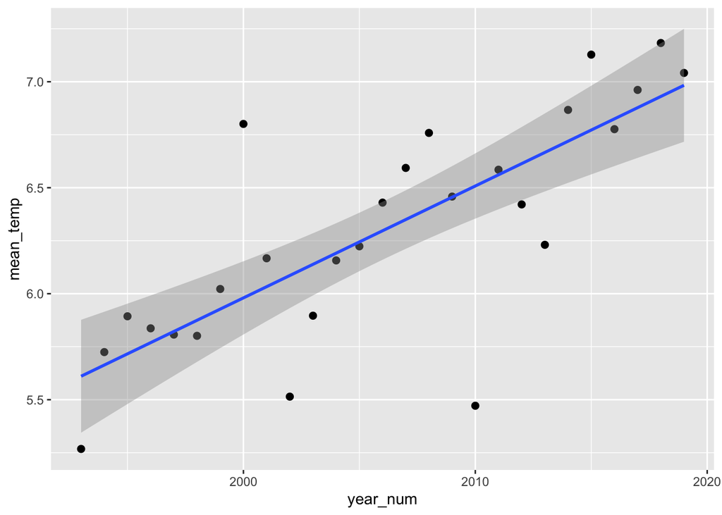

```r
# Plot data, looks like there's big inter-annual variation but a positive trend
big_raster_dat_temp %>%
  group_by(year) %>%
  drop_na(temp) %>%
  summarise(mean_temp = mean(temp)) %>%
  mutate(year_num = as.numeric(year)) %>%
  ggplot(., aes(year_num, mean_temp)) +
  geom_point(size = 2) +
  stat_smooth(method = "lm")
```

```r
# Now add in the new temperature column in the original data:
str(d_sub_temp)
```

```
#> tibble [97,549 × 13] (S3: tbl_df/tbl/data.frame)
#>  $ weight_g : num [1:97549] 11 120 1416 25 733 ...
#>  $ length_cm: num [1:97549] 10 22 51 14 41 41 42 43 43 43 ...
#>  $ year     : int [1:97549] 1993 1993 1993 1993 1993 1993 1993 1993 1993 1993 ...
#>  $ lat      : num [1:97549] 54.7 54.7 54.7 54.5 54.5 ...
#>  $ lon      : num [1:97549] 13.1 13.1 13.1 14.3 14.3 ...
#>  $ quarter  : int [1:97549] 4 4 4 4 4 4 4 4 4 4 ...
#>  $ IDx      : chr [1:97549] "1993.4.GFR.06S1.H20.21.65" "1993.4.GFR.06S1.H20.21.65" "1993.4.GFR.06S1.H20.21.65" "1993.4.GFR.06S1.H20.22.43" ...
#>  $ ices_rect: chr [1:97549] "38G3" "38G3" "38G3" "38G4" ...
#>  $ sub_div  : chr [1:97549] "24" "24" "24" "24" ...
#>  $ depth    : num [1:97549] 7.87 7.87 7.87 6.87 6.87 ...
#>  $ id_oxy   : chr [1:97549] "1993_13.05_54.6667" "1993_13.05_54.6667" "1993_13.05_54.6667" "1993_14.3167_54.5167" ...
#>  $ oxy      : num [1:97549] 7.22 7.22 7.22 7.84 7.84 ...
#>  $ year_f   : Factor w/ 27 levels "1993","1994",..: 1 1 1 1 1 1 1 1 1 1 ...
```

```r
str(big_dat_temp)
```

```
#> tibble [97,549 × 4] (S3: tbl_df/tbl/data.frame)
#>  $ lon : num [1:97549] 13.1 13.1 13.1 14.3 14.3 ...
#>  $ lat : num [1:97549] 54.7 54.7 54.7 54.5 54.5 ...
#>  $ temp: num [1:97549] 7.75 7.75 7.75 7.36 7.36 ...
#>  $ year: chr [1:97549] "1993" "1993" "1993" "1993" ...
```

```r
# Create an ID for matching the temperature data with the cpue data
dat$id_temp <- paste(dat$year, dat$lon, dat$lat, sep = "_")
big_dat_temp$id_temp <- paste(big_dat_temp$year, big_dat_temp$lon, big_dat_temp$lat, sep = "_")

# Which id's are not in the cpue data (dat)? (It's because I don't have those years, not about the location)
ids <- dat$id_temp[!dat$id_temp %in% c(big_dat_temp$id_temp)]

unique(ids)
```

```
#> character(0)
```

```r
# Select only the columns we want to merge
big_dat_sub_temp <- big_dat_temp %>% dplyr::select(id_temp, temp)

# Remove duplicate ID (one temp value per id)
big_dat_sub_temp2 <- big_dat_sub_temp %>% distinct(id_temp, .keep_all = TRUE)
```

```
#> distinct: removed 94,310 rows (97%), 3,239 rows remaining
```

```r
# Join the data with raster-derived oxygen with the full cpue data
dat <- left_join(dat, big_dat_sub_temp2, by = "id_temp")
```

```
#> left_join: added one column (temp)
#>            > rows only in x        0
#>            > rows only in y  (     0)
#>            > matched rows     97,549
#>            >                 ========
#>            > rows total       97,549
```

```r
colnames(dat)
```

```
#>  [1] "weight_g"  "length_cm" "year"      "lat"       "lon"       "quarter"
#>  [7] "IDx"       "ices_rect" "sub_div"   "depth"     "id_oxy"    "oxy"
#> [13] "id_temp"   "temp"
```

```r
dat <- dat %>% dplyr::select(-id_temp, -id_oxy)

# Drop NA temp
dat <- dat %>% drop_na(temp)
```

```
#> drop_na: no rows removed
```

## Add UTM coords

```r
# First add UTM coords
# Add UTM coords
# Function
LongLatToUTM <- function(x, y, zone){
  xy <- data.frame(ID = 1:length(x), X = x, Y = y)
  coordinates(xy) <- c("X", "Y")
  proj4string(xy) <- CRS("+proj=longlat +datum=WGS84")  ## for example
  res <- spTransform(xy, CRS(paste("+proj=utm +zone=",zone," ellps=WGS84",sep='')))
  return(as.data.frame(res))
}

utm_coords <- LongLatToUTM(dat$lon, dat$lat, zone = 33)
dat$X <- utm_coords$X/1000 # for computational reasons
dat$Y <- utm_coords$Y/1000 # for computational reasons
```

## Add cod and flounder density covariates

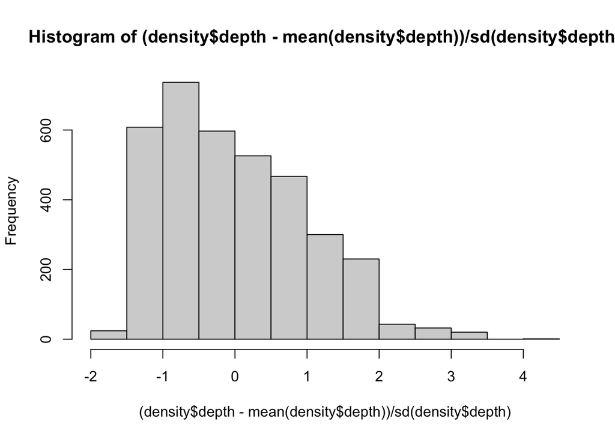

```r
# This is so that we can standardize the prediction grid with respect to the data
density <- readr::read_csv("https://raw.githubusercontent.com/maxlindmark/cod_condition/master/data/for_analysis/catch_q_1_4.csv")

density <- density %>% filter(quarter == 4)

# Load models
mcod <- readRDS("output/mcod.rds")
mfle <- readRDS("output/mfle.rds")

# We need to scale data with respect to the mean and sd in the data to it was fitted to (cpue data)
density_mean_depth <- mean(density$depth)
density_sd_depth <- sd(density$depth)

# Scale depth in the data
dat <- dat %>%
  mutate(depth_sc = (depth - density_mean_depth) / density_sd_depth)

hist((density$depth - mean(density$depth)) / sd(density$depth))
```

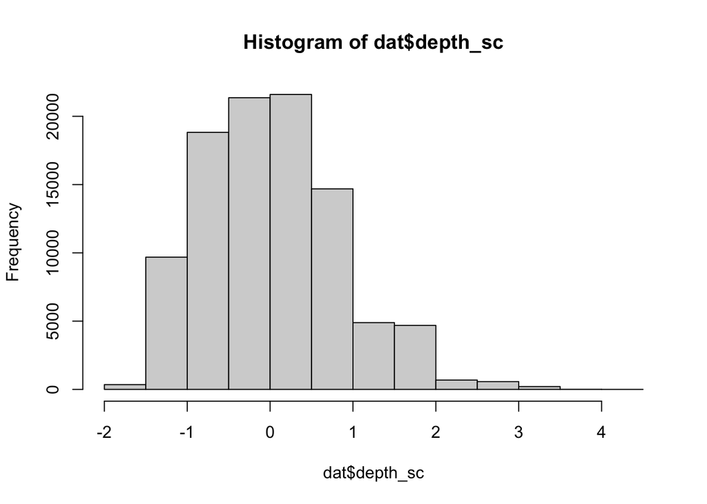

```r
hist(dat$depth_sc)
```

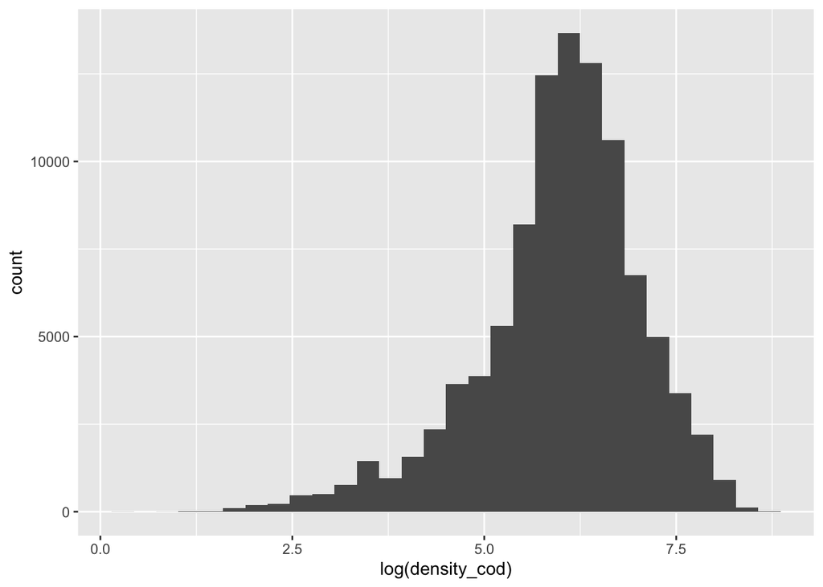

```r
# Predict from the density models
cpue_cod <- exp(predict(mcod, newdata = dat)$est)
cpue_fle <- exp(predict(mfle, newdata = dat)$est)

dat$density_cod <- cpue_cod
dat$density_fle <- cpue_fle

# Inspect
ggplot(dat, aes(log(density_cod))) + geom_histogram()
```

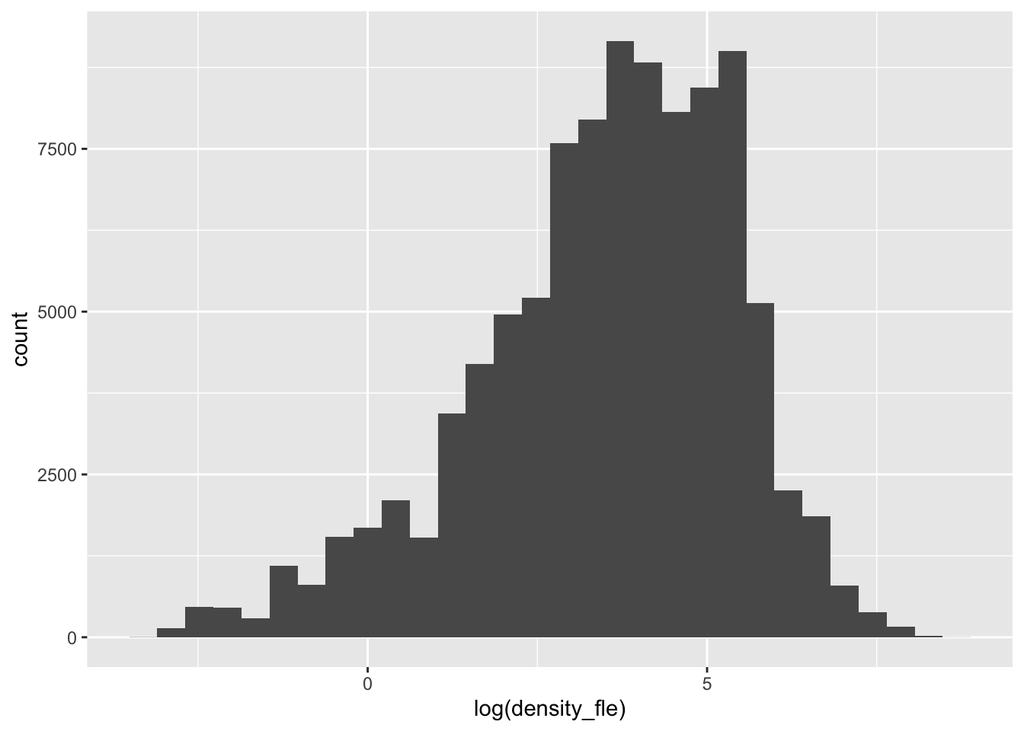

```r
ggplot(dat, aes(log(density_fle))) + geom_histogram()
```

```r
# Remove the scaled depth variable
dat <- dat %>% dplyr::select(-depth_sc)
```